# Does the Software Make the Patent?

- Show All Code
- Hide All Code
- View Source

Maximum Likelihood, Poisson Regression, and the Blueprinty Question

Author

Published

May 14, 2026

## Introduction

Blueprinty makes software designed to help engineers prepare and submit patent applications to the US Patent Office. Their marketing team has a compelling hypothesis: firms that use Blueprinty’s software win more patents. If true, that’s a powerful selling point.

The problem is that the ideal experiment — tracking each firm’s patent success *before* and *after* adopting the software — doesn’t exist. What Blueprinty *does* have is a cross-sectional snapshot of **1,500 mature engineering firms**, each characterized by the number of patents awarded over the past five years, their regional location, years since incorporation, and whether or not they are a Blueprinty customer.

This is useful, but it creates a subtle challenge. Blueprinty’s customers didn’t choose the software at random. Firms that seek out specialized patent-application software are likely already more sophisticated, better resourced, or more patent-focused than average. Any raw difference in patent counts between customers and non-customers might reflect those underlying traits — not the software. Untangling the software’s effect from the characteristics of the firms that chose it is the central statistical challenge here.

We address it in three stages: first by exploring the data to understand who Blueprinty’s customers are, then by building a Poisson model from first principles using maximum likelihood, and finally by using regression to hold firm characteristics constant and isolate the estimated effect of the software.

## Exploring the Data

```r
df <- read_csv("blueprinty.csv") |>
  mutate(
    customer_label = if_else(iscustomer == 1, "Customer", "Non-Customer"),
    customer_label = factor(customer_label, levels = c("Customer", "Non-Customer"))
  )
```

### Patent Counts by Customer Status

We begin with the most direct question: do Blueprinty customers accumulate more patents?

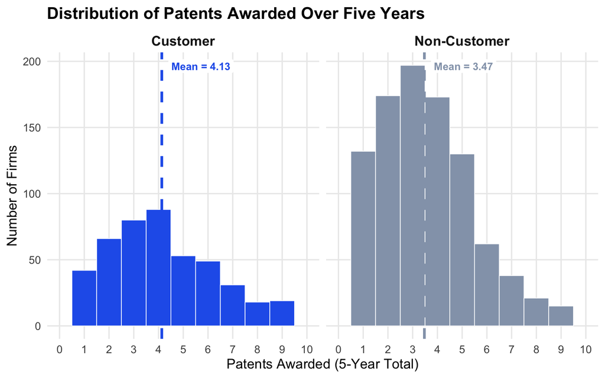

Patent counts are right-skewed in both groups, but customers cluster at higher values.

Summary Statistics: Patents by Customer Status

| Customer Status | Number of Firms | Mean Patents | Median Patents | Std Dev |
| --- | --- | --- | --- | --- |
| Customer | 481 | 4.133 | 4 | 2.547 |
| Non-Customer | 1019 | 3.473 | 3 | 2.225 |

### Are Customers Different Kinds of Firms?

To understand whether the raw patent gap could be confounded, we need to ask: are Blueprinty’s customers systematically different from non-customers in terms of age and geography?

#### Regional Distribution

[figure not shown]

#### Firm Age

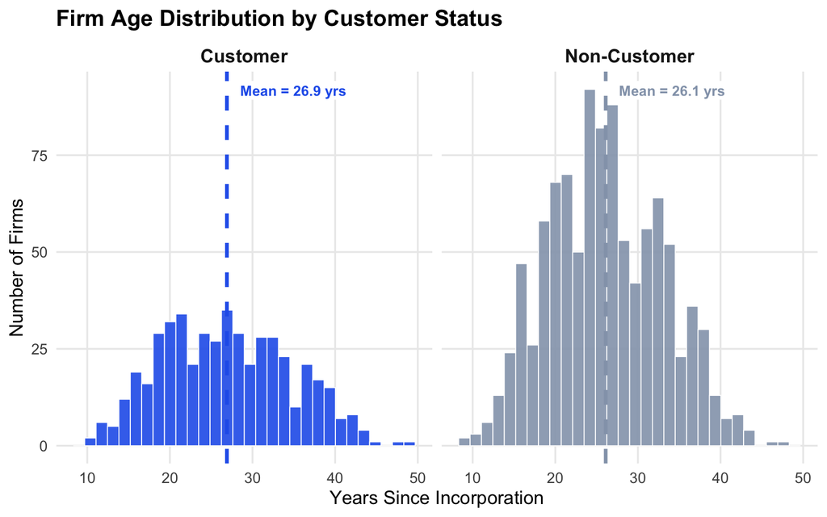

## A Simple Poisson Model via Maximum Likelihood

### Why Poisson?

Our outcome — the number of patents awarded over five years — is a **non-negative integer**. This rules out the Normal distribution as a natural fit: Normal models can assign probability to negative values and don’t respect the integer structure of counts. The **Poisson distribution** is the canonical starting point for count data. It has a single parameter $\lambda > 0$ that equals both the mean and the variance, and it assigns positive probability only to $\{0, 1, 2, \ldots\}$.

We begin with the simplest version: all firms share a common rate $\lambda$.

### Deriving the Log-Likelihood

For an individual observation $Y_i$, the Poisson probability mass function is:

$$f(Y_i \mid \lambda) = \frac{e^{-\lambda} \lambda^{Y_i}}{Y_i!}$$

Assuming the $n$ observations are independent, the **joint likelihood** is the product of individual likelihoods:

$$L(\lambda \mid \mathbf{Y}) = \prod_{i=1}^{n} \frac{e^{-\lambda} \lambda^{Y_i}}{Y_i!}
= \frac{e^{-n\lambda} \lambda^{\sum Y_i}}{\prod_{i=1}^{n} Y_i!}$$

Taking the natural log converts the product into a sum and makes optimization tractable:

$$\ell(\lambda) = \log L(\lambda \mid \mathbf{Y}) = -n\lambda + \left(\sum_{i=1}^{n} Y_i\right) \log\lambda - \sum_{i=1}^{n} \log(Y_i!)$$

**Analytical MLE:** Taking the derivative with respect to $\lambda$ and setting it to zero:

$$\frac{d\ell}{d\lambda} = -n + \frac{\sum Y_i}{\lambda} = 0
\implies \hat{\lambda}_{\text{MLE}} = \frac{\sum Y_i}{n} = \bar{Y}$$

The MLE is simply the sample mean — an intuitive result, since $\lambda$ is the expected value of a Poisson random variable.

### Coding and Plotting the Log-Likelihood

```r
poisson_loglikelihood <- function(lambda, Y) {
  if (any(lambda <= 0)) return(-Inf)
  n <- length(Y)
  -n * lambda + sum(Y) * log(lambda) - sum(lgamma(Y + 1))
}
```

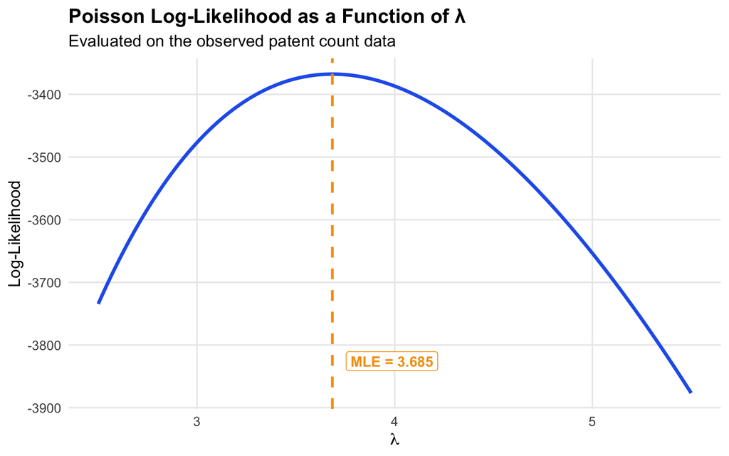

The log-likelihood peaks at the sample mean — the MLE. The curve’s curvature reflects estimation uncertainty.

The curve rises steeply from low values of $\lambda$, reaches its peak at the sample mean, and then falls off more gradually for larger values. The peak is the MLE — the value of $\lambda$ that makes the observed data most probable under the Poisson model.

### Numerical Verification

```r
result_simple <- optim(
  par     = 3,
  fn      = function(lam) -poisson_loglikelihood(lam, Y_obs),
  method  = "Brent",
  lower   = 0.01,
  upper   = 20
)

tibble(
  Method       = c("Analytical (sample mean)", "Numerical (optim)"),
  `λ̂ estimate` = c(round(mean(Y_obs), 6), round(result_simple$par, 6))
) |>
  gt() |>
  tab_header(title = "MLE Comparison: Analytical vs. Numerical") |>
  tab_style(style = cell_text(weight = "bold"), locations = cells_column_labels()) |>
  opt_stylize(style = 1, color = "blue") |>
  tab_options(table.width = pct(55))
```

MLE Comparison: Analytical vs. Numerical

| Method | λ̂ estimate |
| --- | --- |
| Analytical (sample mean) | 3.684667 |
| Numerical (optim) | 3.684667 |

The numerical optimizer returns a value essentially identical to the sample mean. This confirms both that our log-likelihood function is correctly coded and that the analytical derivation ($\hat\lambda = \bar{Y}$) is correct.

## Poisson Regression

### From a Shared Rate to Firm-Specific Rates

$$Y_i \sim \text{Poisson}(\lambda_i) \qquad \text{where} \qquad \lambda_i = \exp(X_i'\beta)$$

We use the **exponential link** for a clean reason: the linear predictor $X_i'\beta$ can take any real value (positive or negative), but $\lambda_i$ must be strictly positive. The exponential maps $\mathbb{R} \to \mathbb{R}^+$, keeping the rate on the correct domain. It also makes the model multiplicative: each one-unit increase in a covariate multiplies $\lambda_i$ by $e^{\beta_j}$, which is natural for rates.

### Building the Covariate Matrix

```r
df_model <- df |>
  mutate(
    age2   = age^2,
    r_mw   = as.integer(region == "Midwest"),
    r_ne   = as.integer(region == "Northeast"),
    r_nw   = as.integer(region == "Northwest"),
    r_sw   = as.integer(region == "Southwest")
    # South is the reference category (dropped to avoid perfect collinearity)
  )

X <- cbind(
  intercept = 1,
  df_model[, c("age", "age2", "r_mw", "r_ne", "r_nw", "r_sw", "iscustomer")]
) |> as.matrix()

Y <- df_model$patents
```

The design matrix $X$ contains:

- **Intercept** — a column of ones.
- **Age and Age²** — we include the quadratic term because the relationship between firm maturity and patent activity is unlikely to be linear. Young firms may ramp up patenting as they develop IP; very old firms may plateau. The quadratic captures this potential curvature.
- **Region indicators** — four binary variables for Midwest, Northeast, Northwest, and Southwest, with **South as the reference category**. Including all five regions would create perfect collinearity with the intercept (they would sum to 1 for every observation), so we must omit one.
- **Customer indicator** — the key variable of interest.

### Log-Likelihood for Poisson Regression

```r
poisson_regression_loglikelihood <- function(beta, Y, X) {
  lambda <- exp(X %*% beta)
  sum(-lambda + Y * log(lambda) - lgamma(Y + 1))
}
```

### Finding the MLE via `optim()`

```r
beta_init <- rep(0, ncol(X))

result_reg <- optim(
  par     = beta_init,
  fn      = function(b) -poisson_regression_loglikelihood(b, Y, X),
  method  = "BFGS",
  hessian = TRUE
)

beta_hat <- result_reg$par
se_hat   <- sqrt(diag(solve(result_reg$hessian)))
z_vals   <- beta_hat / se_hat
p_vals   <- 2 * (1 - pnorm(abs(z_vals)))

coef_names <- c("Intercept", "Age", "Age²", "Midwest", "Northeast",
                "Northwest", "Southwest", "Customer")

results_tbl <- tibble(
  Covariate = coef_names,
  Estimate  = beta_hat,
  `Std. Error` = se_hat,
  `z-value`    = z_vals,
  `p-value`    = p_vals
)
```

The standard errors are computed as the square roots of the diagonal of the **negative inverse Hessian** — the inverse of the observed Fisher information matrix. Intuitively, the Hessian measures how sharply the log-likelihood curves around its maximum; a sharper peak means more information about the parameter, and therefore a smaller standard error.

### Verification with `glm()`

```r
# Explicitly set South as reference region so GLM matches our manual X matrix
df_model <- df_model |>
  mutate(region = relevel(factor(region), ref = "South"))

glm_fit <- glm(
  patents ~ age + I(age^2) + region + iscustomer,
  data   = df_model,
  family = poisson(link = "log")
)
```

Poisson Regression: optim() vs. glm()

| Covariate | Manual MLE (optim) Estimate (optim) | Manual MLE (optim) SE (optim) | Built-in GLM Estimate (glm) | Built-in GLM SE (glm) |
| --- | --- | --- | --- | --- |
| Intercept | −0.12573 | 0.11226 | −0.45236 | 0.18289 |
| Age | 0.11592 | 0.00636 | 0.14862 | 0.01387 |
| Age² | −0.00223 | 0.00008 | −0.00297 | 0.00026 |
| Midwest | −0.02336 | 0.05253 | −0.05656 | 0.05266 |
| Northeast | −0.02454 | 0.04570 | −0.02739 | 0.04510 |
| Northwest | −0.03482 | 0.05497 | −0.07414 | 0.05515 |
| Southwest | −0.03778 | 0.04946 | −0.00599 | 0.04874 |
| Customer | 0.06068 | 0.03205 | 0.20759 | 0.03090 |

### Interpreting the Regression Results

Poisson Regression Results<sup>1</sup>

Outcome: Patents awarded over 5 years | Reference region: South<sup>1</sup>

| Covariate | Estimate | Std. Error | z-value | p-value | Stars | Exp(β) |
| --- | --- | --- | --- | --- | --- | --- |
| Intercept | −0.1257 | 0.1123 | −1.1200 | 0.2627 |  | 0.8819 |
| Age | 0.1159 | 0.0064 | 18.2256 | 0.0000 | *** | 1.1229 |
| Age² | −0.0022 | 0.0001 | −28.8934 | 0.0000 | *** | 0.9978 |
| Midwest | −0.0234 | 0.0525 | −0.4447 | 0.6565 |  | 0.9769 |
| Northeast | −0.0245 | 0.0457 | −0.5370 | 0.5913 |  | 0.9758 |
| Northwest | −0.0348 | 0.0550 | −0.6335 | 0.5264 |  | 0.9658 |
| Southwest | −0.0378 | 0.0495 | −0.7637 | 0.4450 |  | 0.9629 |
| Customer | 0.0607 | 0.0320 | 1.8935 | 0.0583 | · | 1.0626 |

<sup>1</sup> Significance: *** p<0.001, ** p<0.01, * p<0.05, · p<0.1

## The Effect of Blueprinty’s Software

Poisson regression coefficients describe multiplicative effects on the *rate* $\lambda_i$, not additive effects on the *count* directly. To answer “how many additional patents does the software correspond to?”, we use the **average marginal effect** approach — sometimes called counterfactual prediction.

### Counterfactual Predictions

We construct two versions of the covariate matrix: one where every firm is set to non-customer status ($X_0$), and one where every firm is set to customer status ($X_1$). Everything else — age, region — is held at its observed value.

```r
beta_glm <- coef(glm_fit)

make_X_for_glm <- function(df, customer_val) {
  df |>
    mutate(iscustomer = customer_val) |>
    model.matrix(~ age + I(age^2) + region + iscustomer, data = _)
}

X0 <- make_X_for_glm(df_model, 0)
X1 <- make_X_for_glm(df_model, 1)

yhat0 <- exp(X0 %*% beta_glm)
yhat1 <- exp(X1 %*% beta_glm)

avg_effect <- mean(yhat1 - yhat0)
```

Estimated Effect of Blueprinty Software on Patent Awards

|  | Value |
| --- | --- |
| Avg. predicted patents (non-customer) | 3.4362 |
| Avg. predicted patents (customer) | 4.2290 |
| Average marginal effect of Blueprinty | 0.7928 |

After holding firm age and region fixed at their observed values for each firm, the model estimates that **Blueprinty customers average approximately 0.79 additional patents** over five years relative to what they would have been expected to produce without the software.

### What This Analysis Does — and Doesn’t — Establish

That said, **this is an observational study**, not a randomized experiment. We cannot rule out that customers and non-customers differ on unobserved dimensions — perhaps in their internal IP teams, their industry focus, or their management sophistication — that simultaneously drive software adoption and patent success. The `iscustomer` coefficient absorbs all of these unmeasured differences, not just the software’s causal effect.

A properly randomized trial, in which a random subset of similar firms was given access to Blueprinty’s software, would be needed to establish causality. Absent that, our estimate is best read as an **association** that survives adjustment for observable firm characteristics — suggestive, but not conclusive.